# Factor Analysis of Portuguese Wine Chemical Properties

Álvaro Granados Villodre

2025-May

## Introduction

This project uses **factor analysis** to explore how different chemical properties in Portuguese red wine relate to each other. The goal is to find latent factors that explain these relationships and reduce the number of dimensions in the dataset without losing important information about wine composition.

The analysis uses the [Wine Quality dataset](https://archive.ics.uci.edu/dataset/186/wine+quality) from the UCI Machine Learning Repository.  
The dataset was originally published by Cortez et al. (2009):

> Cortez, P., Cerdeira, A., Almeida, F., Matos, T., & Reis, J. (2009).  
> *Modeling wine preferences by data mining from physicochemical properties*.  
> *Decision Support Systems, 47*(4), 547–553. https://doi.org/10.1016/j.dss.2009.05.016

The dataset includes detailed measurements of chemical attributes that define wine quality and composition. Factor analysis works well for this type of data because it can show how different chemical properties group together and reveal the main dimensions that characterize wines.

I’m focusing on six key chemical variables:

- **residual.sugar**: sugar remaining after fermentation
- **density**: wine density (affected by alcohol and sugar content)
- **pH**: acidity level on a 0-14 scale
- **alcohol**: alcohol content by volume
- **citric.acid**: citric acid level (adds freshness and complexity)
- **volatile.acidity**: acetic acid level (high amounts create a vinegar taste)

```r
suppressPackageStartupMessages(library(tidyverse))
wine_df <- read_delim("winequality-red.csv",
                      delim = ";",
                      show_col_types = FALSE)
str(wine_df)
```

```
## spc_tbl_ [1,599 × 12] (S3: spec_tbl_df/tbl_df/tbl/data.frame)
##  $ fixed acidity       : num [1:1599] 7.4 7.8 7.8 11.2 7.4 7.4 7.9 7.3 7.8 7.5 ...
##  $ volatile acidity    : num [1:1599] 0.7 0.88 0.76 0.28 0.7 0.66 0.6 0.65 0.58 0.5 ...
##  $ citric acid         : num [1:1599] 0 0 0.04 0.56 0 0 0.06 0 0.02 0.36 ...
##  $ residual sugar      : num [1:1599] 1.9 2.6 2.3 1.9 1.9 1.8 1.6 1.2 2 6.1 ...
##  $ chlorides           : num [1:1599] 0.076 0.098 0.092 0.075 0.076 0.075 0.069 0.065 0.073 0.071 ...
##  $ free sulfur dioxide : num [1:1599] 11 25 15 17 11 13 15 15 9 17 ...
##  $ total sulfur dioxide: num [1:1599] 34 67 54 60 34 40 59 21 18 102 ...
##  $ density             : num [1:1599] 0.998 0.997 0.997 0.998 0.998 ...
##  $ pH                  : num [1:1599] 3.51 3.2 3.26 3.16 3.51 3.51 3.3 3.39 3.36 3.35 ...
##  $ sulphates           : num [1:1599] 0.56 0.68 0.65 0.58 0.56 0.56 0.46 0.47 0.57 0.8 ...
##  $ alcohol             : num [1:1599] 9.4 9.8 9.8 9.8 9.4 9.4 9.4 10 9.5 10.5 ...
##  $ quality             : num [1:1599] 5 5 5 6 5 5 5 7 7 5 ...
##  - attr(*, "spec")=
##   .. cols(
##   ..   `fixed acidity` = col_double(),
##   ..   `volatile acidity` = col_double(),
##   ..   `citric acid` = col_double(),
##   ..   `residual sugar` = col_double(),
##   ..   chlorides = col_double(),
##   ..   `free sulfur dioxide` = col_double(),
##   ..   `total sulfur dioxide` = col_double(),
##   ..   density = col_double(),
##   ..   pH = col_double(),
##   ..   sulphates = col_double(),
##   ..   alcohol = col_double(),
##   ..   quality = col_double()
##   .. )
##  - attr(*, "problems")=<externalptr>
```

## Data Preparation

For this analysis, I’m selecting the six chemical variables listed above. The original dataset has more variables, but these six give good coverage of the main chemical properties.

```r
selected_variables <- c("residual sugar", "density", "pH", "alcohol", "citric acid", "volatile acidity")

wine_filtered_df <- wine_df %>% select(all_of(selected_variables))
str(wine_filtered_df)
```

```
## tibble [1,599 × 6] (S3: tbl_df/tbl/data.frame)
##  $ residual sugar  : num [1:1599] 1.9 2.6 2.3 1.9 1.9 1.8 1.6 1.2 2 6.1 ...
##  $ density         : num [1:1599] 0.998 0.997 0.997 0.998 0.998 ...
##  $ pH              : num [1:1599] 3.51 3.2 3.26 3.16 3.51 3.51 3.3 3.39 3.36 3.35 ...
##  $ alcohol         : num [1:1599] 9.4 9.8 9.8 9.8 9.4 9.4 9.4 10 9.5 10.5 ...
##  $ citric acid     : num [1:1599] 0 0 0.04 0.56 0 0 0.06 0 0.02 0.36 ...
##  $ volatile acidity: num [1:1599] 0.7 0.88 0.76 0.28 0.7 0.66 0.6 0.65 0.58 0.5 ...
```

## Factor Analysis Implementation

The factor analysis is implemented using two factors, as preliminary analysis suggests that wine chemical properties can be effectively summarized into two principal dimensions. The hypothesis is that these factors will represent distinct aspects of wine chemistry, potentially related to acidity characteristics and physical properties.

```r
# Factor analysis computation with 2 factors
wine_filtered_df.fa <- factanal(wine_filtered_df, factors = 2)
print(wine_filtered_df.fa)
```

```
##
## Call:
## factanal(x = wine_filtered_df, factors = 2)
##
## Uniquenesses:
##   residual sugar          density               pH          alcohol
##            0.874            0.005            0.681            0.654
##      citric acid volatile acidity
##            0.005            0.635
##
## Loadings:
##                  Factor1 Factor2
## residual sugar            0.343
## density           0.225   0.972
## pH               -0.514  -0.234
## alcohol           0.194  -0.555
## citric acid       0.987   0.147
## volatile acidity -0.583   0.158
##
##                Factor1 Factor2
## SS loadings      1.675   1.471
## Proportion Var   0.279   0.245
## Cumulative Var   0.279   0.524
##
## Test of the hypothesis that 2 factors are sufficient.
## The chi square statistic is 252.24 on 4 degrees of freedom.
## The p-value is 2.14e-53
```

## Analysis of Variable Representation

The factor analysis results demonstrate significant variation in how well different variables are represented by the extracted factors. Examining the uniquenesses provides insight into variable-specific variance that is not captured by the common factors.

```r
wine_filtered_df.fa$uniquenesses
```

```
##   residual sugar          density               pH          alcohol
##        0.8736706        0.0050000        0.6814500        0.6542943
##      citric acid volatile acidity
##        0.0050000        0.6347011
```

The **residual sugar** variable exhibits a uniqueness value of 0.87, indicating that 87% of its variance is not explained by the extracted factors. This high uniqueness suggests that residual sugar follows patterns independent of the other variables and may not be well-suited for this two-factor model.

Conversely, **density and citric acid** show uniquenesses of 0.005 each, meaning that virtually all their variance (99.5%) is captured by the factor structure. These variables demonstrate excellent fit within the factorial model.

The communalities (1 - uniquenesses) provide the complementary perspective on shared variance:

```r
# Communality calculation
communalities <- 1 - wine_filtered_df.fa$uniquenesses
print(communalities)
```

```
##   residual sugar          density               pH          alcohol
##        0.1263294        0.9950000        0.3185500        0.3457057
##      citric acid volatile acidity
##        0.9950000        0.3652989
```

**Alcohol and volatile acidity** show communalities of approximately 0.35, indicating that about 35% of their variance is explained by the common factors. This represents moderate but meaningful representation in the factor structure.

## Factor 1 Interpretation

Analysis of Factor 1 loadings reveals the variables that contribute most strongly to this dimension:

```r
# Extract Factor 1 loadings
factor1_loadings <- wine_filtered_df.fa$loadings[, 1, drop = FALSE]

# Display loadings graphically
suppressPackageStartupMessages(library(psych))
print(factor1_loadings)
```

```
##                      Factor1
## residual sugar    0.09474219
## density           0.22472020
## pH               -0.51377880
## alcohol           0.19374024
## citric acid       0.98654894
## volatile acidity -0.58348331
```

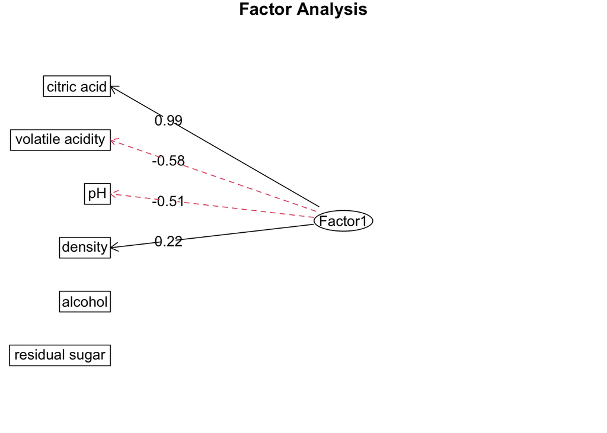

```r
fa.diagram(factor1_loadings, cut=0.2, digits=2)
```

Factor 1 represents an **acidity dimension** with the following loading pattern:

- **Citric acid** shows a strong positive loading (0.987)
- **Volatile acidity** exhibits a negative loading (-0.583)
- **pH** demonstrates an inverse relationship (-0.514)
- **Density** has a moderate positive loading (0.22)

This factor structure is chemically coherent, as citric acid contributes to beneficial acidity, while high pH (alkalinity) and volatile acidity (associated with wine defects) load negatively on this dimension.

## Factor 2 Interpretation

Factor 2 loadings indicate a different underlying dimension:

```r
# Extract Factor 2 loadings
factor2_loadings <- wine_filtered_df.fa$loadings[, 2, drop = FALSE]

# Display loadings graphically
print(factor2_loadings)
```

```
##                     Factor2
## residual sugar    0.3425707
## density           0.9718554
## pH               -0.2336242
## alcohol          -0.5551314
## citric acid       0.1473950
## volatile acidity  0.1576323
```

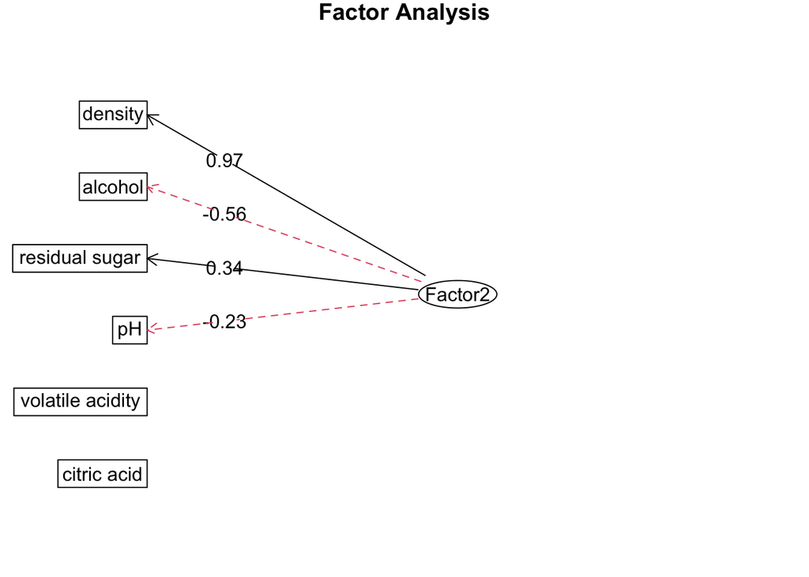

```r
fa.diagram(factor2_loadings, cut=0.2, digits=2)
```

This factor captures the physical properties of wine, particularly the inverse relationship between density and alcohol content, which reflects fundamental physical chemistry principles.

## Model Adequacy Assessment

The factor solution demonstrates reasonable explanatory power:

```r
wine_filtered_df.fa$loadings
```

```
##
## Loadings:
##                  Factor1 Factor2
## residual sugar            0.343
## density           0.225   0.972
## pH               -0.514  -0.234
## alcohol           0.194  -0.555
## citric acid       0.987   0.147
## volatile acidity -0.583   0.158
##
##                Factor1 Factor2
## SS loadings      1.675   1.471
## Proportion Var   0.279   0.245
## Cumulative Var   0.279   0.524
```

The two-factor model explains 52.4% of total variance, distributed as 27.9% for Factor 1 and 24.5% for Factor 2. This balanced contribution suggests that both factors are meaningful for understanding wine composition.

Using the Kaiser criterion (eigenvalues > 1), both factors qualify for retention: - Factor 1: eigenvalue = 1.675 - Factor 2: eigenvalue = 1.471

## Validation Through Correlation Analysis

Different rotation methods are applied to confirm factor interpretability and examine the correlation structure:

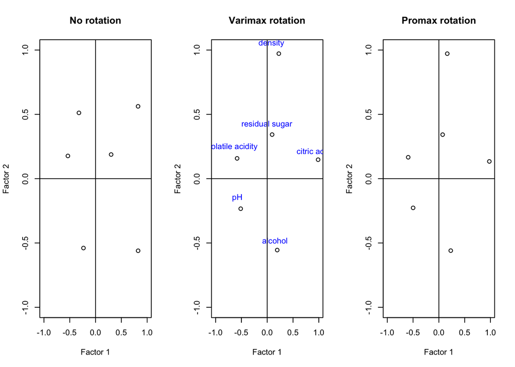

```r
# Factor analysis with different rotation methods
wine_filtered_df.fa.none <- factanal(wine_filtered_df, factors = 2, rotation="none")
wine_filtered_df.fa.varimax <- factanal(wine_filtered_df, factors = 2, rotation="varimax")
wine_filtered_df.fa.promax <- factanal(wine_filtered_df, factors = 2, rotation="promax")

par(mfrow = c(1,3))

# No rotation plot
plot(wine_filtered_df.fa.none$loadings[,1],
     wine_filtered_df.fa.none$loadings[,2],
     xlab = "Factor 1",
     ylab = "Factor 2",
     ylim = c(-1,1),
     xlim = c(-1,1),
     main = "No rotation")
abline(h = 0, v = 0)

# Varimax rotation plot
plot(wine_filtered_df.fa.varimax$loadings[,1],
     wine_filtered_df.fa.varimax$loadings[,2],
     xlab = "Factor 1",
     ylab = "Factor 2",
     ylim = c(-1,1),
     xlim = c(-1,1),
     main = "Varimax rotation")

# Variable labels
text(wine_filtered_df.fa.promax$loadings[,1]-0.08,
     wine_filtered_df.fa.promax$loadings[,2]+0.08,
      colnames(wine_filtered_df),
      col="blue")
abline(h = 0, v = 0)

# Promax rotation plot
plot(wine_filtered_df.fa.promax$loadings[,1],
     wine_filtered_df.fa.promax$loadings[,2],
     xlab = "Factor 1",
     ylab = "Factor 2",
     ylim = c(-1,1),
     xlim = c(-1,1),
     main = "Promax rotation")
abline(h = 0, v = 0)
```

```r
# Correlation matrix analysis
suppressPackageStartupMessages(library(corrplot))
wine_correlation_matrix <- cor(wine_filtered_df)
print(wine_correlation_matrix)
```

```
##                  residual sugar     density          pH     alcohol citric acid
## residual sugar      1.000000000  0.35528337 -0.08565242  0.04207544   0.1435772
## density             0.355283371  1.00000000 -0.34169933 -0.49617977   0.3649472
## pH                 -0.085652422 -0.34169933  1.00000000  0.20563251  -0.5419041
## alcohol             0.042075437 -0.49617977  0.20563251  1.00000000   0.1099032
## citric acid         0.143577162  0.36494718 -0.54190414  0.10990325   1.0000000
## volatile acidity    0.001917882  0.02202623  0.23493729 -0.20228803  -0.5524957
##                  volatile acidity
## residual sugar        0.001917882
## density               0.022026232
## pH                    0.234937294
## alcohol              -0.202288027
## citric acid          -0.552495685
## volatile acidity      1.000000000
```

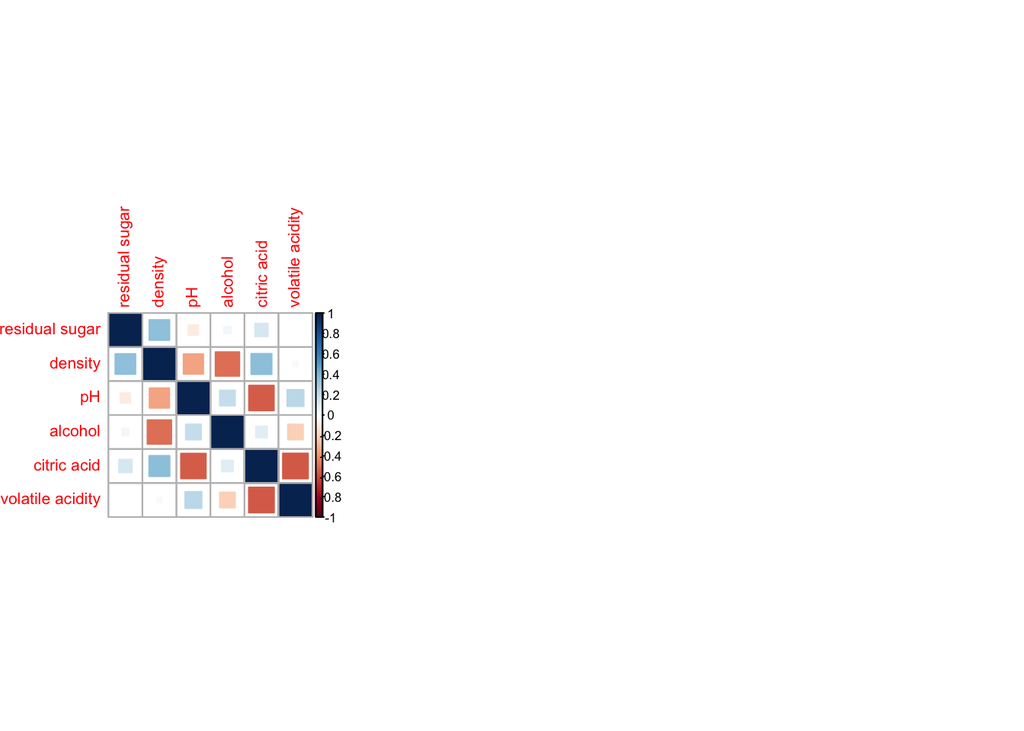

```r
corrplot(wine_correlation_matrix, method = "square")
```

The varimax rotation provides optimal simple structure, while the correlation matrix confirms the expected relationships between acidity-related variables and between density and alcohol.

## Relationship Visualization

Scatter plots illustrate the bivariate relationships between key variables:

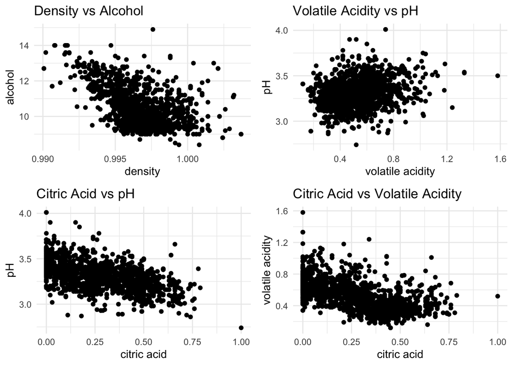

```r
library(cowplot)
# Create bivariate scatter plots
density_alcohol_plot <- ggplot(data = wine_filtered_df, aes(x = density, y = alcohol)) +
  geom_point() +
  ggtitle("Density vs Alcohol") +
  theme_minimal()

volatile_acidity_ph_plot <- ggplot(data = wine_filtered_df, aes(x = `volatile acidity`, y = pH)) +
  geom_point() +
  ggtitle("Volatile Acidity vs pH") +
  theme_minimal()

citric_acid_ph_plot <- ggplot(data = wine_filtered_df, aes(x = `citric acid`, y = pH)) +
  geom_point() +
  ggtitle("Citric Acid vs pH") +
  theme_minimal()

citric_volatile_plot <- ggplot(data = wine_filtered_df, aes(x = `citric acid`, y = `volatile acidity`)) +
  geom_point() +
  ggtitle("Citric Acid vs Volatile Acidity") +
  theme_minimal()

# Display plots in grid format
cowplot::plot_grid(density_alcohol_plot, volatile_acidity_ph_plot,
                   citric_acid_ph_plot, citric_volatile_plot, ncol = 2)
```

## Results and Discussion

The factor analysis successfully identified two interpretable dimensions underlying Portuguese wine chemical composition:

**Factor 1 - Acidity Profile**: This dimension captures the acid balance in wine, with citric acid loading positively and volatile acidity and pH loading negatively. This factor represents the beneficial acidity that contributes to wine quality and flavor complexity.

**Factor 2 - Physical Structure**: This dimension is dominated by density and its inverse relationship with alcohol content. It represents the physical characteristics that affect wine body and mouthfeel.

The analysis reveals that **residual sugar** is poorly represented in this two-factor model, suggesting that sugar content varies independently of the primary chemical dimensions identified. This finding indicates that residual sugar may require separate analysis or additional factors for comprehensive modeling.

## Conclusions

Factor analysis proves effective for understanding the dimensionality of wine chemical data. The two-factor solution provides interpretable dimensions that correspond to meaningful chemical and physical properties. The acidity profile factor captures quality-related chemical characteristics, while the physical structure factor represents fundamental physical properties affecting wine characteristics.

These results have practical implications for wine quality assessment and production monitoring, as they identify the key dimensions that drive chemical variation in Portuguese red wines. The methodology demonstrates the utility of factor analysis for reducing complex chemical datasets to interpretable underlying dimensions while maintaining chemical and physical coherence in the factor structure.